# Standard Meta Analysis Template for Correlations

## About the analysis

Analyses were conducted using the file dat.molloy2014.csv, to examine the relationship between Intention and Behaviour. Correlation coefficents were transformed to Fisher Z correlation coefficents for analysis and backtransformed for reporting.

It is expected that datafiles for analysis are provided in the format outlined here: https://osf.io/6bk7b/wiki/Correlation%20Data%20Format/

## Data importing and effect size calculation

Read dat.molloy2014.csv into R

```r
#Read your datafile into R
mydata<-read.csv(filename)
```

First few rows of the imported data

| X | authors | year | ni | ri | controls | design | a_measure | c_measure | meanage | quality |
| --- | --- | --- | --- | --- | --- | --- | --- | --- | --- | --- |
| 1 | Axelsson et al. | 2009 | 109 | 0.187 | none | cross-sectional | self-report | other | 22.00 | 1 |
| 2 | Axelsson et al. | 2011 | 749 | 0.162 | none | cross-sectional | self-report | NEO | 53.59 | 1 |

Calculate r-to-z transformed correlations and corresponding sampling variances

```r
library(metafor)
# calculate r-to-z transformed correlations and corresponding sampling variances
dat <- escalc(ri=ri, ni=ni, measure=specified.measure, data=mydata, append=TRUE)
```

First few rows of the effect size table

| X | authors | year | ni | ri | controls | design | a_measure | c_measure | meanage | quality | yi | vi |
| --- | --- | --- | --- | --- | --- | --- | --- | --- | --- | --- | --- | --- |
| 1 | Axelsson et al. | 2009 | 109 | 0.187 | none | cross-sectional | self-report | other | 22.00 | 1 | 0.1892266 | 0.0094340 |
| 2 | Axelsson et al. | 2011 | 749 | 0.162 | none | cross-sectional | self-report | NEO | 53.59 | 1 | 0.1634399 | 0.0013405 |

## Conducting the meta-analyis

```r
# Run the random effect meta-analysis
res <- rma(yi, vi, data=dat)
weightr_effect <- res$yi
weightr_var <- res$vi

weightr_res <- weightfunct(weightr_effect, weightr_var)

# Back transform z to r correlations for reporting if ZCOR was used
transformed<-ifelse(specified.measure=="ZCOR",
                    res_back<-predict(res, tranf=transf.ztor),
                    res_back<-predict(res))

# need to come back to this later
weightr_transformed<-ifelse(specified.measure=="ZCOR",
                    weightr_res_back<-predict(res, tranf=transf.ztor),
                    weightr_res_back<-predict(res))

# Create a table of information from the res model
res.table<-cbind.data.frame(res_back$pred, res_back$se,
                            res$pval, res_back$ci.lb, res_back$ci.ub,  res$k)
colnames(res.table)<-c("r", "se", "p", "CI.LB", "CI.UB", "k")
row.names(res.table)<-paste(X,"-",Y)

# Create a table of heterogeneity information
het.table<-cbind.data.frame(res$tau2, res$se.tau2, res$QE,
                            res$QEp, res$I2, res_back$cr.lb, res_back$cr.ub)
colnames(het.table)<-c("tau2", "se.tau2", "Q", "p", "I2", "cr.lb", "cr.ub")
row.names(het.table)<-paste(X,"-",Y)

# Create a table of information from the res model
weightr_res.table<-cbind.data.frame(weightr_res_back$pred, weightr_res_back$se,
                            res$pval, weightr_res_back$ci.lb, weightr_res_back$ci.ub,  res$k)
colnames(weightr_res.table)<-c("r", "se", "p", "CI.LB", "CI.UB", "k")
row.names(weightr_res.table)<-paste(X,"-",Y)

# Create a table of heterogeneity information
weightr_het.table<-cbind.data.frame(res$tau2, res$se.tau2, res$QE,
                            res$QEp, res$I2, weightr_res_back$cr.lb, weightr_res_back$cr.ub)
colnames(weightr_het.table)<-c("tau2", "se.tau2", "Q", "p", "I2", "cr.lb", "cr.ub")
row.names(weightr_het.table)<-paste(X,"-",Y)
```

## Results

**Summary**

This analysis is based on 16 studies that evaluated the relationship between Intention and Behaviour. Correlation coefficents were transformed to Fisher Z correlation coefficents for analysis and backtransformed for reporting.

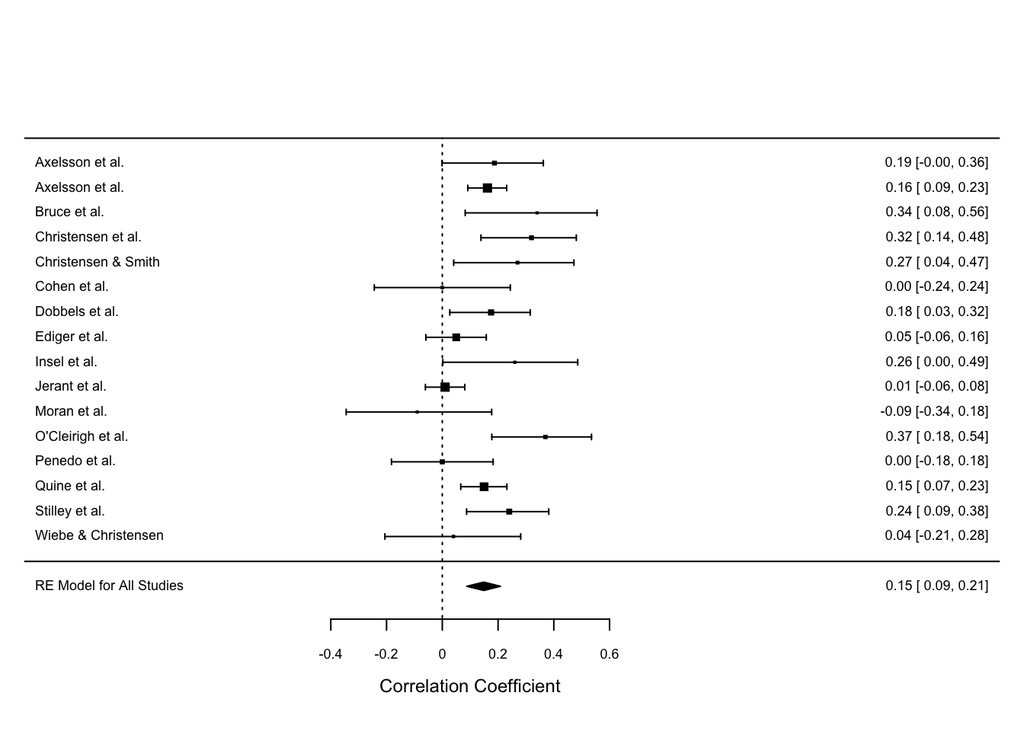

**What is the strength of the association between Intention and Behaviour?**

A random effects meta-analysis was conducted (k=16) to explore the association between Intention and Behaviour. The average correlation between these variables is r<sub>+</sub>=0.15, (p=0, 95% CI [0.09, 0.21]). See table below.

Meta-Analysis Summary Table

|  | r | se | p | CI Lower | CI Upper | k |
| --- | --- | --- | --- | --- | --- | --- |
| Intention - Behaviour | 0.15 | 0.032 | 0 | 0.088 | 0.212 | 16 |

|  | r | se | p | CI Lower | CI Upper | k |
| --- | --- | --- | --- | --- | --- | --- |
| Intention - Behaviour | 0.15 | 0.032 | 0 | 0.088 | 0.212 | 16 |

**Does the strength of the association vary across studies?**

A Cochran’s Q test was conducted to examine whether variations in the observed correlation are likely to be attributable soley to sampling error (Q<sub>(df=15)</sub>=38.16, p=<.001). The variation in the correlation is greater than would be expected from sampling error alone. It appears that the true correlation varies betweeen studies.

The I<sup>2</sup> statistics indicates the *proportion* of variance in the observed effect attributable to sampling error. In this instance, the I<sup>2</sup> = 61.73%.

Note, this statistic is not an absolute measure of heterogeneity (although it is often interpreted as such). We strongly advise against using rules of thumb such as “small”, “medium” or “large” when interpreting I<sup>2</sup> values. Instead, researchers increasingly argue that the information provided credibility or prediction intervals is more useful in understanding the heterogeneity of true effect sizes in meta-analysis. In this instance the 95% credibility intervals are -0.04,0.34. That is, it is estimated that 95% of true correlations fall between r=-0.04 and r=0.34.

Heterogeneity statistics are summarised below

Heterogeneity Summary Table

|  | $\tau$<sup>2</sup> | se $\tau$<sup>2</sup> | Q | p | I<sup>2</sup> | Credibility Lower | Credibility Upper |
| --- | --- | --- | --- | --- | --- | --- | --- |
| Intention - Behaviour | 0.008 | 0.006 | 38.16 | 0.001 | 61.732 | -0.037 | 0.337 |

# Notes